# Data table manipulation

Jim Félix-Faure

22/10/2020

**Note** : To follow this workshop it is recommended to have already completed the following courses *Fast data manipulation with dplyr and its allies* and *Rapid data visualization with ggplot2* (available on the *Numerilab* website - see link at the bottom of this document) or to have some basics on the use of the *pipe operator*, *ggplot2* and the basic functions of the *tidyverse*.

# Change table format

To optimize processing and/or visualization, it is recommended that the data tables under R be organized as follows :

- Each **column** is a **variable**..
- Each **row** is an **observation**.
- Each **cell** is composed of **one value**.

Let’s see some examples where this is not the case, and the solutions to apply using the `tidyr` package, included with the `tidyverse`.

## From *wide* format to *longer* format

Here is an example where values are hidden in column names.  
The weight of observations *A* and *B* is reported according to the year.

```r
library(tidyverse)
Tbl_Weight <- tibble(
  Observation = c("A", "B"),
  "2010" = c(3, 3),
  "2011" = c(5, 2),
  "2012" = c(4, 3),
  "2013" = c(5, 3)
)
Tbl_Weight
```

```
# A tibble: 2 x 5
  Observation `2010` `2011` `2012` `2013`
  <chr>        <dbl>  <dbl>  <dbl>  <dbl>
1 A                3      5      4      5
2 B                3      2      3      3
```

How to compute the average weight of each observation? How to draw a graph representing the weight of each observation over time?

Not so easy, unless you reorganize the data. Here the objective is twofold:

- create a variable `Year` grouping the years present in the name of the columns.
- create a variable `Weight` grouping the weight values keeping the correspondence with the years.

```r
Tbl_WeightTidy <- Tbl_Weight %>%
  pivot_longer(
    cols = !Observation, # Columns to be used
    names_to = "Year", # Variable where the column names will be stored
    names_transform = list(Year = as.integer), # Choice of variable type for names_to
    values_to = "Weight" # Variable where the values will be stored
  )
Tbl_WeightTidy
```

```
# A tibble: 8 x 3
  Observation  Year Weight
  <chr>       <int>  <dbl>
1 A            2010      3
2 A            2011      5
3 A            2012      4
4 A            2013      5
5 B            2010      3
6 B            2011      2
7 B            2012      3
8 B            2013      3
```

The average weight of observations :

```r
Tbl_WeightTidy %>%
  group_by(Observation) %>%
  summarise(Mean = mean(Weight),
            Sd = sd(Weight),
            n = n())
```

```
# A tibble: 2 x 4
  Observation  Mean    Sd     n
  <chr>       <dbl> <dbl> <int>
1 A            4.25 0.957     4
2 B            2.75 0.5       4
```

Graph of weights as a function of years :

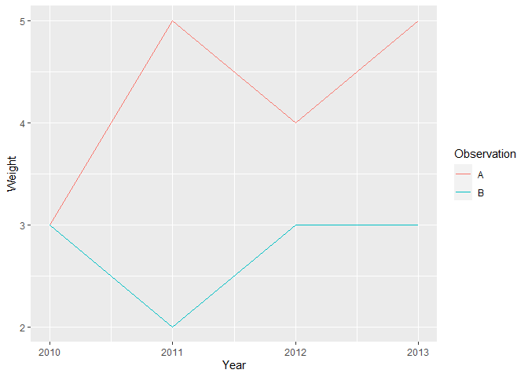

```r
Tbl_WeightTidy %>%
  ggplot() +
  geom_line(aes(x = Year, y = Weight, color = Observation))
```

## From *large* format to *wider* format

Sometimes the problem is reversed. One observation is present in several rows and several variables are in the same column.

```r
Tbl_Water <- tibble(
  Observation = rep(c("A", "B", "C", "D"), each = 2),
  Measure = rep(c("pH", "O2"), 4),
  Value = c(6, 99, 7, 90, 7.2, 85, 6.5, 96)
)
Tbl_Water
```

```
# A tibble: 8 x 3
  Observation Measure Value
  <chr>       <chr>   <dbl>
1 A           pH        6
2 A           O2       99
3 B           pH        7
4 B           O2       90
5 C           pH        7.2
6 C           O2       85
7 D           pH        6.5
8 D           O2       96
```

Again, it is not easy to graph the relationship between `pH` and `O2` and the units in the `Value` column are not clear.

```r
Tbl_WaterTidy <- Tbl_Water %>%
  pivot_wider(names_from = Measure, # column that contains the variable names
              values_from = Value # column that contains the values
              )
Tbl_WaterTidy
```

```
# A tibble: 4 x 3
  Observation    pH    O2
  <chr>       <dbl> <dbl>
1 A             6      99
2 B             7      90
3 C             7.2    85
4 D             6.5    96
```

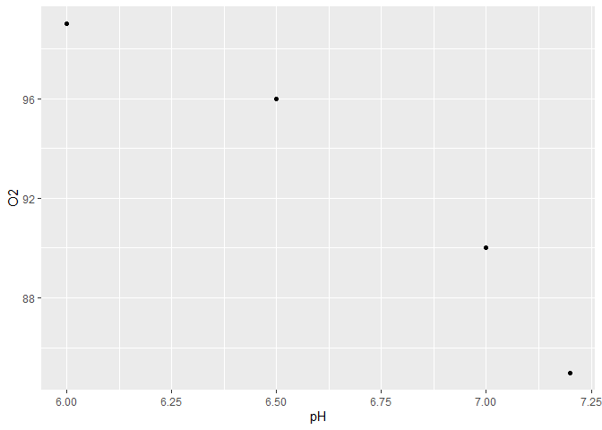

```r
Tbl_WaterTidy %>%
  ggplot(aes(x = pH, y = O2)) +
  geom_point()
```

# Split two values from one cell

When entering data, it can happen that two values are put together in the same cell.  
For example, here are the results of the number of animals positive to a molecule on the number of animals tested.

```r
Tbl_Effect <- tibble(
  Molecule = c("A","B","C"),
  Result = c("87/112","23/48","34/89")
)
Tbl_Effect
```

```
# A tibble: 3 x 2
  Molecule Result
  <chr>    <chr>
1 A        87/112
2 B        23/48
3 C        34/89
```

We want to calculate the ratio between positive and tested animals.

The `separate()` function allows you to split the contents of one `character` column into several other `character` or `numeric` columns. It cuts out every character that is neither a number nor a letter. If necessary, the separator can be specified manually with the argument `sep=""`.

```r
Tbl_Effect %>%
  separate(
    col = Result, # which column to separate
    into = c("Positive_animals", "Tested_animals"), # how to call the new columns
    convert = TRUE, # convert the new columns to the appropriate type
    remove = TRUE # remove the former column
  ) %>%
  mutate(Ratio = Positive_animals/Tested_animals)
```

```
# A tibble: 3 x 4
  Molecule Positive_animals Tested_animals Ratio
  <chr>               <int>          <int> <dbl>
1 A                      87            112 0.777
2 B                      23             48 0.479
3 C                      34             89 0.382
```

# Data set connection

## The joins

As the number, source, and diversity of the data increase, it is common to have multiple data tables. In this case, it is possible to connect them using a **key**. Its nature can vary (`character`, `factor`, `numeric`…) but it is essential that this key be a **unique value for each observation**.

Let’s take a look at an example:

```r
Tbl_Site <- tibble(
  Site = c("356a", "da4b", "77de", "1b64"),
  Landuse = c("Forest", "Forest", "Pasture", "Wetland"),
  Area = c(12, 30, 8, 17)
)
Tbl_Site
```

```
# A tibble: 4 x 3
  Site  Landuse  Area
  <chr> <chr>   <dbl>
1 356a  Forest     12
2 da4b  Forest     30
3 77de  Pasture     8
4 1b64  Wetland    17
```

```r
Tbl_Result <- tibble(
  Site = c("1b64", "1b64", "356a", "da4b", "da4b", "abcd"),
  Measure = c("pH", "pH", "Corg", "pH", "Corg", "Corg"),
  Value = c(7, 7.2, 3.5, 5.8, 2.7, 5.8)
)
Tbl_Result
```

```
# A tibble: 6 x 3
  Site  Measure Value
  <chr> <chr>   <dbl>
1 1b64  pH        7
2 1b64  pH        7.2
3 356a  Corg      3.5
4 da4b  pH        5.8
5 da4b  Corg      2.7
6 abcd  Corg      5.8
```

As see below, there are many functions for joining data tables.

### Full joins

The `full_join()` function allows to make a full join between two arrays. It will keep **all** the data of each table, at the risk of creating gaps (`NA`) when some information is not present in one or the other table.

```r
full_join(Tbl_Site, Tbl_Result, by = "Site")
```

```
# A tibble: 7 x 5
  Site  Landuse  Area Measure Value
  <chr> <chr>   <dbl> <chr>   <dbl>
1 356a  Forest     12 Corg      3.5
2 da4b  Forest     30 pH        5.8
3 da4b  Forest     30 Corg      2.7
4 77de  Pasture     8 <NA>     NA
5 1b64  Wetland    17 pH        7
6 1b64  Wetland    17 pH        7.2
7 abcd  <NA>       NA Corg      5.8
```

The `by=` argument is used to specify on which variable to join. In our example, `Site` is used as the common key to both arrays.

### Left joins

The `left_join()` function makes a left join. Which means on `x`, the table on the left. It will keep all the data from `x` and add the data from the right table (`y`) without incorporating data that does not match.

```r
left_join(Tbl_Site, Tbl_Result, by = "Site")
```

```
# A tibble: 6 x 5
  Site  Landuse  Area Measure Value
  <chr> <chr>   <dbl> <chr>   <dbl>
1 356a  Forest     12 Corg      3.5
2 da4b  Forest     30 pH        5.8
3 da4b  Forest     30 Corg      2.7
4 77de  Pasture     8 <NA>     NA
5 1b64  Wetland    17 pH        7
6 1b64  Wetland    17 pH        7.2
```

Note that the new table does not contain the `abcd` site, not present in `x` (`Tbl_Site`).

### Right joins

In the same way the `right_join()` function makes a right join (on `y`).

```r
right_join(Tbl_Site, Tbl_Result, by = "Site")
```

```
# A tibble: 6 x 5
  Site  Landuse  Area Measure Value
  <chr> <chr>   <dbl> <chr>   <dbl>
1 356a  Forest     12 Corg      3.5
2 da4b  Forest     30 pH        5.8
3 da4b  Forest     30 Corg      2.7
4 1b64  Wetland    17 pH        7
5 1b64  Wetland    17 pH        7.2
6 abcd  <NA>       NA Corg      5.8
```

Note that the new table does not contain the `77de` site, not present in `y` (`Tbl_Result`).

### Filtering joins

The `semi_join` and `anti_join` functions allow to *filter* data table according to another.

`semi_join` will return all lines in `x` for which **there is a match** in `y`. Only the columns of `x` will be returned.

```r
semi_join(Tbl_Site, Tbl_Result, by = "Site")
```

```
# A tibble: 3 x 3
  Site  Landuse  Area
  <chr> <chr>   <dbl>
1 356a  Forest     12
2 da4b  Forest     30
3 1b64  Wetland    17
```

In contrast, `anti_join` will return all lines in `x` for which **there is no match** in `y`. Only the columns of `x` will be returned.

```r
anti_join(Tbl_Site, Tbl_Result, by = "Site")
```

```
# A tibble: 1 x 3
  Site  Landuse  Area
  <chr> <chr>   <dbl>
1 77de  Pasture     8
```

## Bind data table

When the structure of the data tables is similar, it is sometimes preferable to bind these tables to form a single one.

In this example, we will use land-use data collected in 1970 and 2020 on the same site. In 2020, the areas of each site have been added.

```r
Tbl_Site1970 <- tibble(
  Site = c("356a", "da4b", "77de", "1b64"),
  Landuse = c("Crop", "Pasture", "Pasture", "Wetland")
)
Tbl_Site2020 <- tibble(
  Site = c("356a", "da4b", "77de", "1b64"),
  Landuse = c("Forest", "Forest", "Pasture", "Crop"),
  Area = c(12, 30, 8, 17)
)
Tbl_Site1970
```

```
# A tibble: 4 x 2
  Site  Landuse
  <chr> <chr>
1 356a  Crop
2 da4b  Pasture
3 77de  Pasture
4 1b64  Wetland
```

```r
Tbl_Site2020
```

```
# A tibble: 4 x 3
  Site  Landuse  Area
  <chr> <chr>   <dbl>
1 356a  Forest     12
2 da4b  Forest     30
3 77de  Pasture     8
4 1b64  Crop       17
```

There are two ways to do this:

### By columns

With `bind_cols`, the `y` table is **inserted to the right** of the `x` table. The number of rows in `x` and `y` must be the identical. If column names are repeated the function adds a number behind the column name of `y`.  
In most cases, a join is preferable…

```r
bind_cols(Tbl_Site1970, Tbl_Site2020)
```

```
* Site -> Site...1
* Landuse -> Landuse...2
* Site -> Site...3
* Landuse -> Landuse...4
```

```
# A tibble: 4 x 5
  Site...1 Landuse...2 Site...3 Landuse...4  Area
  <chr>    <chr>       <chr>    <chr>       <dbl>
1 356a     Crop        356a     Forest         12
2 da4b     Pasture     da4b     Forest         30
3 77de     Pasture     77de     Pasture         8
4 1b64     Wetland     1b64     Crop           17
```

Sometimes it is useful to extract a variable from a data table without importing the initial table:

```r
bind_cols(Tbl_Site1970, select(Tbl_Site2020, Area))
```

```
# A tibble: 4 x 3
  Site  Landuse  Area
  <chr> <chr>   <dbl>
1 356a  Crop       12
2 da4b  Pasture    30
3 77de  Pasture     8
4 1b64  Wetland    17
```

**Warning**: Both tables must be ordered in the same way.

### By rows

With `bind_rows`, the `y` table is **inserted under** the `x` table.

```r
bind_rows(Tbl_Site1970, Tbl_Site2020)
```

```
# A tibble: 8 x 3
  Site  Landuse  Area
  <chr> <chr>   <dbl>
1 356a  Crop       NA
2 da4b  Pasture    NA
3 77de  Pasture    NA
4 1b64  Wetland    NA
5 356a  Forest     12
6 da4b  Forest     30
7 77de  Pasture     8
8 1b64  Crop       17
```

Note that not all columns need to be present in both tables. In this case, `NA`s are generated.

The argument `.id` is used to identify which table the data comes from by creating a new column containing the *id*. It is possible to choose the name of the column containing the *id* and the identifier of each table.

```r
bind_rows("1970" = Tbl_Site1970, "2020" = Tbl_Site2020, .id = "Year")
```

```
# A tibble: 8 x 4
  Year  Site  Landuse  Area
  <chr> <chr> <chr>   <dbl>
1 1970  356a  Crop       NA
2 1970  da4b  Pasture    NA
3 1970  77de  Pasture    NA
4 1970  1b64  Wetland    NA
5 2020  356a  Forest     12
6 2020  da4b  Forest     30
7 2020  77de  Pasture     8
8 2020  1b64  Crop       17
```

# Manipulation of *NA*

In a data table, missing values (`NA`) are often a source of problems and difficulties.  
To avoid problems, some machines use a specific code to signify missing or outlier data, for example `9999` or `-9999`. Sometimes it is when entering our data that we use a code, for example `"NoData"`.

In a case like this, to perform analyses we may want to:

## Convert values to *NA*.

The function `na_if(x, y)` is used to convert the values `y` contained in `x` to `NA`. Here is an example:

```r
Tbl_Temperature <- tibble(Site = c("A", "A", "A", "B", "B", "B"),
             Month = c("January", "NoData", "September", "January", "June", "September"),
             Temp = c(-12, 16, 13, 9999, 19, 15 ))
Tbl_Temperature
```

```
# A tibble: 6 x 3
  Site  Month      Temp
  <chr> <chr>     <dbl>
1 A     January     -12
2 A     NoData       16
3 A     September    13
4 B     January    9999
5 B     June         19
6 B     September    15
```

One value is missing in the `Month` variable (`NoData`) and one value is identified as an outlier in the `Temp` variable. We then replace these two values by `NA` as follow:

```r
Tbl_TempNA <- Tbl_Temperature %>%
  mutate(Month = na_if(Month, "NoData")) %>%
  mutate(Temp = na_if(Temp, 9999))
Tbl_TempNA
```

```
# A tibble: 6 x 3
  Site  Month      Temp
  <chr> <chr>     <dbl>
1 A     January     -12
2 A     <NA>         16
3 A     September    13
4 B     January      NA
5 B     June         19
6 B     September    15
```

## Replace *NA*

The `replace_na` function allows you to replace the `NA` with one or more other values.

```r
Tbl_TempNA
```

```
# A tibble: 6 x 3
  Site  Month      Temp
  <chr> <chr>     <dbl>
1 A     January     -12
2 A     <NA>         16
3 A     September    13
4 B     January      NA
5 B     June         19
6 B     September    15
```

```r
Tbl_TempNA %>%
  mutate(Month = replace_na(Month, "June")) %>%
  mutate(Temp = replace_na(Temp, -17))
```

```
# A tibble: 6 x 3
  Site  Month      Temp
  <chr> <chr>     <dbl>
1 A     January     -12
2 A     June         16
3 A     September    13
4 B     January     -17
5 B     June         19
6 B     September    15
```

or :

```r
Tbl_TempNA %>%
  replace_na(list(Month = "June", Temp = -17))
```

```
# A tibble: 6 x 3
  Site  Month      Temp
  <chr> <chr>     <dbl>
1 A     January     -12
2 A     June         16
3 A     September    13
4 B     January     -17
5 B     June         19
6 B     September    15
```

# Working with categorical data

There are two types of categorical data that should not be confused in the *R* environment:

- The `character` type. These data are in the form of a string of characters, coded as follows `"My_character_chain"`. Within the same variable, they are “independent”.
- The `factor` type. This is very similar to the type `character`, except that within a variable *R* creates “groups” of identical factors called `levels`. These “levels” are sorted in ascending order and then alphabetically.

## Towards factorial variables

We first create a character type variable (`Vector_Character`). We see that this variable has no level (`NULL`).

```r
Vector_Character <- c("Apple", "Apple", "Pear", "Apricot", "Pear")
Vector_Character
```

```
[1] "Apple"   "Apple"   "Pear"    "Apricot" "Pear"
```

```r
levels(Vector_Character)
```

[output not shown]

We then convert this variable into a factor type variable. We see that *R* now recognises the three levels of the `Vector_Factor` variable.

```r
Vector_Factor <- factor(Vector_Character)
Vector_Factor
```

```
[1] Apple   Apple   Pear    Apricot Pear
Levels: Apple Apricot Pear
```

```r
levels(Vector_Factor)
```

```
[1] "Apple"   "Apricot" "Pear"
```

In this part of the workshop we will use the `msleep` dataset and the `forcats` package included in the `tidyverse`.

Note: The functions of the `forcats` package automatically interpret `character` data into `factor` data.

**Important** : Non-numeric variables which are imported into *R* in a `tibble` are interpreted as `character`.

## Changing the order of factor levels

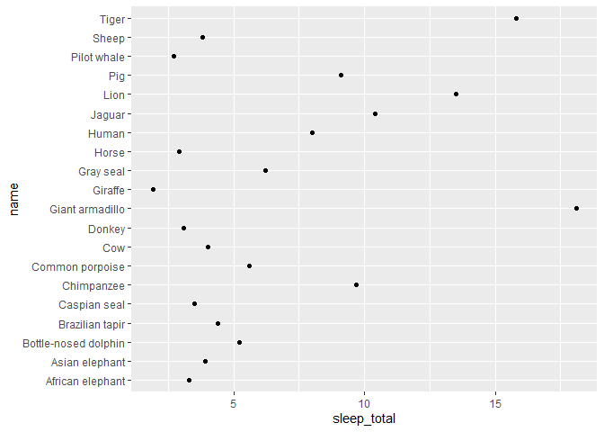

```r
msleep %>%
  top_n(20) %>% # Only the first 20 rows
  ggplot() +
  geom_point(aes(x = sleep_total,
                 y = name))
```

In a case like this, it is possible to reorder the factors according to a variable to make the graph easier to read.

### According to another variable

The function `fct_reorder` is used to order the `levels` of a factorial variable according to another variable.

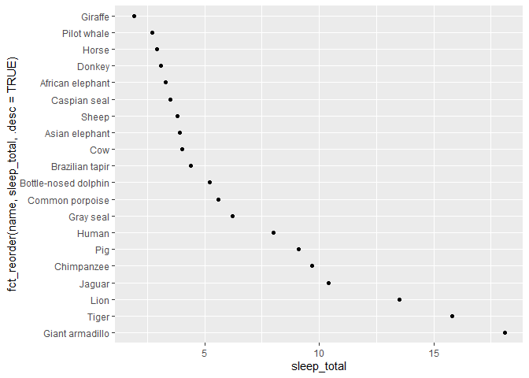

```r
msleep %>%
  top_n(20) %>% # Only the first 20 rows
  ggplot() +
  geom_point(aes(x = sleep_total,
                 y = fct_reorder(name, # variable to sort
                                 sleep_total, # variable on which to sort
                                 .desc = TRUE) # sort in descending order
                 ))
```

### Manually

To manually change the order of the `levels` of a factorial variable we use `fct_relevel`.

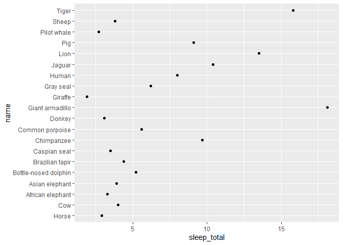

```r
msleep %>%
  top_n(20) %>% # Only the first 20 lines
  mutate(name = fct_relevel(name, # variable to sort
                     "Horse", "Cow")) %>% # "levels" to place first ("1", "2", ...))
  ggplot() +
  geom_point(aes(x = sleep_total,
                 y = name))
```

In this example, `"Horse"` and `"Cow"` have moved into first and second position. The order of the other factors has not been changed. We could also choose the position of one factor in relation to the others using the `after=` argument.

## Changing factor levels

The `fct_recode` function allows to modify a factorial variable according to its levels.

```r
msleep_recode <- msleep %>%
  select(name:vore) %>%  # facilitates visualization of the tibble
  mutate(
    vore = factor(vore), # change the type of variable -> from "character" to "factor".
    vore_recode = fct_recode(vore, # Modifies the levels of the variable
      "Carnivore" = "carni",
      "Herbivore" = "herbi",
      "Autre" = "omni",
      "Autre" = "insecti"
    )
  )
```

```r
levels(msleep_recode$vore)
```

```
[1] "carni"   "herbi"   "insecti" "omni"
```

```r
levels(msleep_recode$vore_recode)
```

```
[1] "Carnivore" "Herbivore" "Autre"
```

```r
msleep_recode
```

```
# A tibble: 83 x 4
   name                       genus       vore  vore_recode
   <chr>                      <chr>       <fct> <fct>
 1 Cheetah                    Acinonyx    carni Carnivore
 2 Owl monkey                 Aotus       omni  Autre
 3 Mountain beaver            Aplodontia  herbi Herbivore
 4 Greater short-tailed shrew Blarina     omni  Autre
 5 Cow                        Bos         herbi Herbivore
 6 Three-toed sloth           Bradypus    herbi Herbivore
 7 Northern fur seal          Callorhinus carni Carnivore
 8 Vesper mouse               Calomys     <NA>  <NA>
 9 Dog                        Canis       carni Carnivore
10 Roe deer                   Capreolus   herbi Herbivore
# ... with 73 more rows
```

# Practice

## Table formatting

Transform the following data sets into a table ready for analysis, considering that the unit of observation is the season.

```r
Tbl_Weather <- tribble(
  ~State, ~Temp, ~Rain,
  "Quebec", 15, 300,
  "Ontario", 17, 280,
  "Manitoba", 12, 360
)
```

`Tbl_Obs` consists of wildlife observations (positive/total).

```r
Tbl_Obs <- tribble(
  ~State, ~Spring, ~Fall,
  "Quebec", "22/30", "10/12",
  "Ontario", "18/50", "3/4"
)
```

The final table should look like this:

```
# A tibble: 4 x 6
  State    Temp  Rain Season Obs_posi Obs_nega
  <chr>   <dbl> <dbl> <chr>     <int>    <int>
1 Quebec     15   300 Spring       22        8
2 Quebec     15   300 Fall         10        2
3 Ontario    17   280 Spring       18       32
4 Ontario    17   280 Fall          3        1
```

## Categorical variable

From the `msleep` data table. Merge carnivorous animals and insectivores into carnivores. Then, display a boxplot of total sleep time by food type, with herbivores, omnivores and carnivores in order.

The final graphic should be this one:

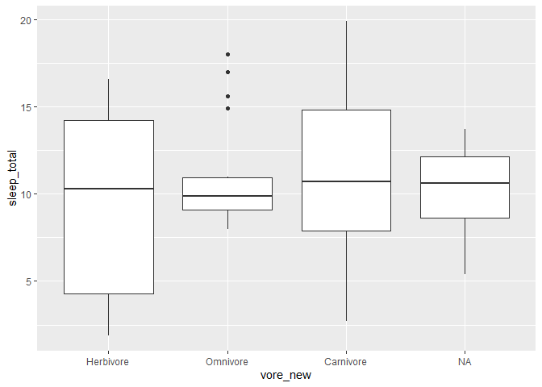

# Useful links

This workshop is largely inspired by free documents and website.  
Thanks to **Charles Martin** PhD student at UQTR for his help.

Here are some useful links to continue:

Your favorite site:

- https://rive-numeri-lab.github.io/

Safe memory help for the `tidyr` package:

- https://tidyr.tidyverse.org/

Safe memory help for the `forcats’ package:

- https://forcats.tidyverse.org/

More generally and to complete on the `tidyverse`:

- https://www.tidyverse.org/